# Lab 4

WADDS

February 7, 2018

## Guiding Question

We want to know if smoking during pregancy affects the gestation period and the birth weights of the baby. We want to know what confounding variables may be influencing the relationship between gestation period and smoking and birth weight and smoking, to determine if there is a relationship between these variables.

We aim to find the relationship between a mother’s smoking habits and premature birth in order to keep the general public–specifically future mothers–informed about the possible risks smoking may cause for their unborn child. If we can find what factors have the most significant affect on premature births, we can help people avoid having a premature child by warning them what habits or actions they take cause the highest risk of that, particularly smoking. It would be important for people who want to be mothers to know what affect smoking could have on their child.

Similarly, it is also important to analyze trends in birth weights at every gestational ages between babies whose mothers smoke and whose mothers do not. Future mothers could benefit from these results, as it can be dangerous for a baby to have too low of a birth weight. By answering these two questions, we will be able to give future parents a better understanding of how smoking habits could impact the birth of their child.

## Do Mothers who smoke have increased rates of premature delivery?

To determine if smoking causes more premature births, we compare the ratio of smokers to non-smokers who have pre-mature births and mature births.

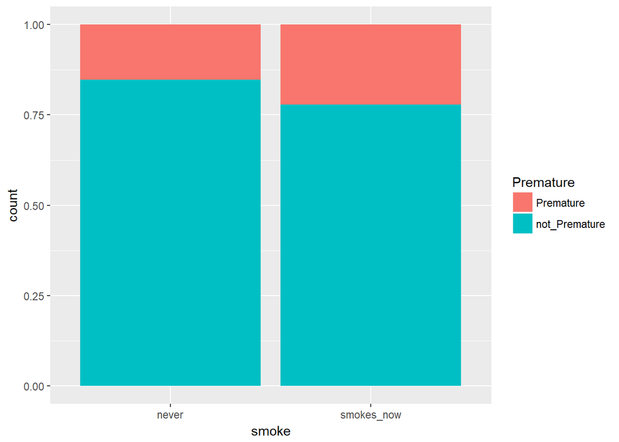

```r
na.omit(babies) %>%
  ggplot(aes(smoke, fill = Premature)) +
  geom_bar(position = "fill")
```

In the above plot we can see a higher percent of premature births among smokers vs non-smokers. The difference is not large and may be due to other factors, but warrants further investigation. Keys things to look into is whether the the premature births increase as the number of cigarretes smoked per day increases, the proportion of premature births to mothers who never smoked, smoked up until pregrant, and smoked through their pregnancy. Unfortunately this data was either not present or not present is a statistically signicant quantity.

## Do the newborns of mothers who smoke have smaller birth weights at every gestational age?

We want to look at the relationship between gestation time and birth weight. We will compare this relationship among mothers who do and do not smoke. This will allow us to see if smoking affects the birth weight of babies at every gestational age.

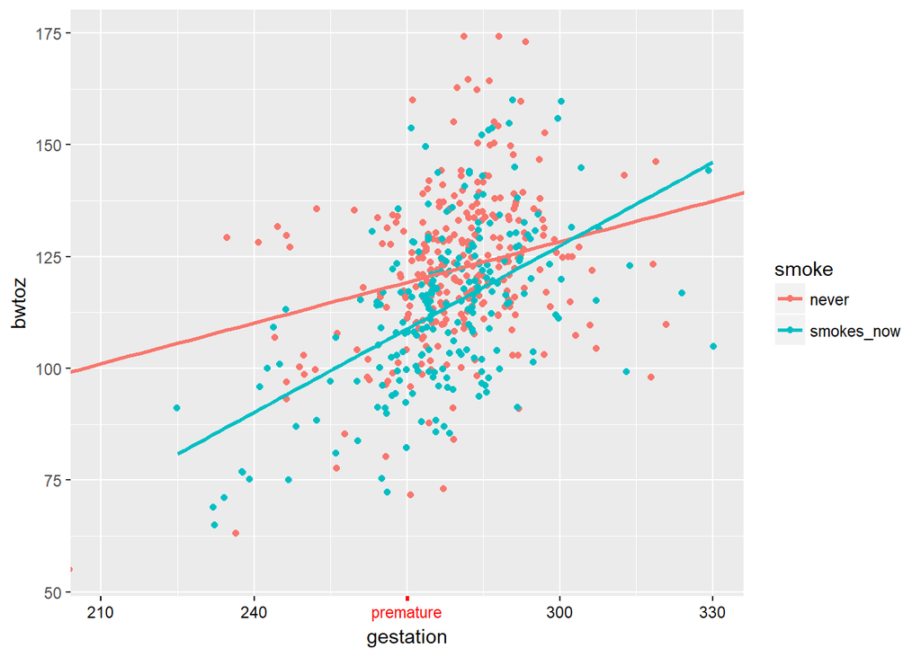

```r
ggplot(data=na.omit(babies), mapping=aes(x=gestation, y=bwtoz,color=smoke)) +
  geom_jitter() +
  geom_smooth(se=FALSE,method="lm") +
  coord_cartesian(xlim=c(210,330)) +
  scale_x_continuous(breaks = c(210,240,270,300,330), labels = c("210","240","premature","300","330")) +
  theme(axis.text.x = element_text(color = c("black", "black", "red", "black", "black")),
        axis.ticks.x = element_line(color = c("black", "black", "red", "black", "black"),
                          size = c(.5,.5,1,.5,.5,.5)))
```

As we can see from the plots above, the newborns of mothers who currently smoke have a lower birth weight at every gestational age until around the 300th day. At this point, however, if a child is far enough into the pregnancy with a smoking mother, then it would make sense for the birth weight to be larger. This would imply a likelier chance for survival, as more weight would make them more resilient to unhealthy environments. Up until this point we can see that babies of mothers who do smoke have much smaller weights than the babies of mothers who do not smoke.

## Preliminary Question

Which variables are similar among smokers and non-smokers? This is what we will be analyzing in our individual parts below.

## Mother’s Height to Weight Ratio

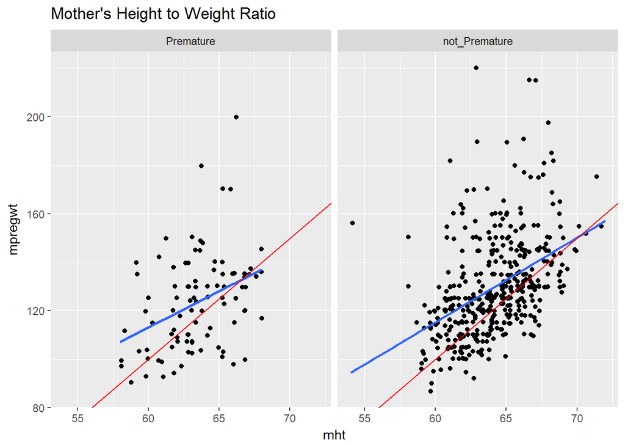

The red line indicates a generally accepted standard of what a healthy woman would weigh close to for her given height. This baseline was created from the estimate on livestrong.com. It is important to note that this baseline is general, and what is considered healthy varies from person to person. The blue line is the linear approximation the mothers’ height to weight ratio within the data.

Though both mothers with premature babies and mothers with non-premature babies have a variety of height to weight ratios, including some that seem to vary significantly from the “healthy” line, there is no significant different in the trends of the mothers with premature babies and the mother of this. Because of this, I would conclude that the mother’s height to weight ratio does not have much of an affect on whether or not the child is premature.

## Father’s Weight to Birthweight

Since most children take after their parents in height once they are fully grown, it would be interesting to note if birthweight is influenced by the weight of the father. If bigger babies have heavier fathers, then this may be a confounding variable in regards to birthweight and smoking. The question I hope to answer is, do father’s weight and birthweight have a strong correlation?

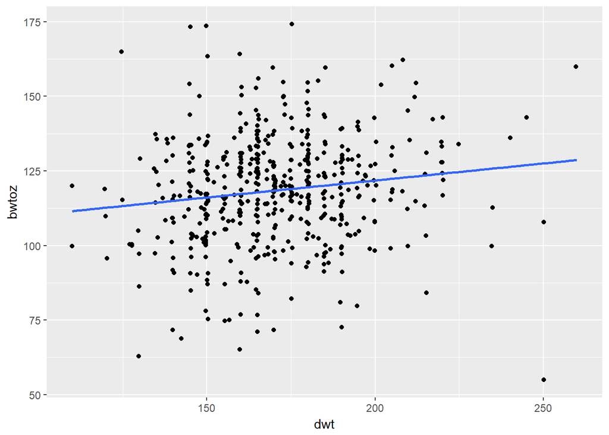

```r
ggplot(data=na.omit(babies), mapping=aes(x=dwt, y=bwtoz))+geom_jitter()+geom_smooth(se=FALSE, method="lm")
```

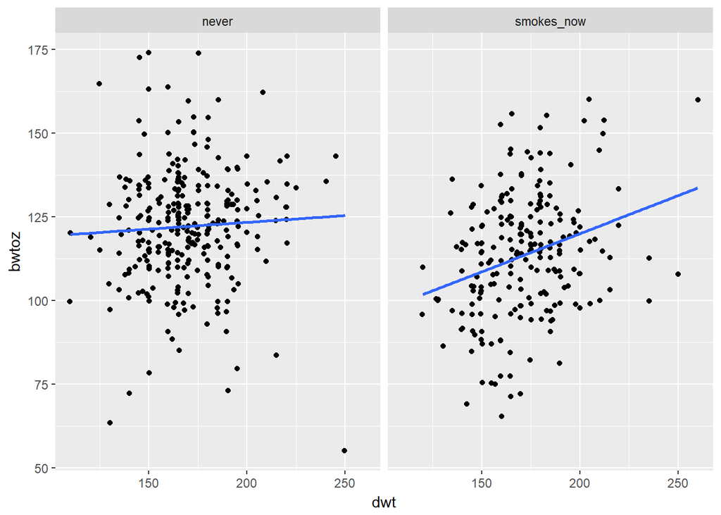

```r
ggplot(data=na.omit(babies), mapping=aes(x=dwt, y=bwtoz))+geom_jitter()+facet_wrap(~smoke)+geom_smooth(se=FALSE, method="lm")
```

## Premature, Smoking, and Birth Weight

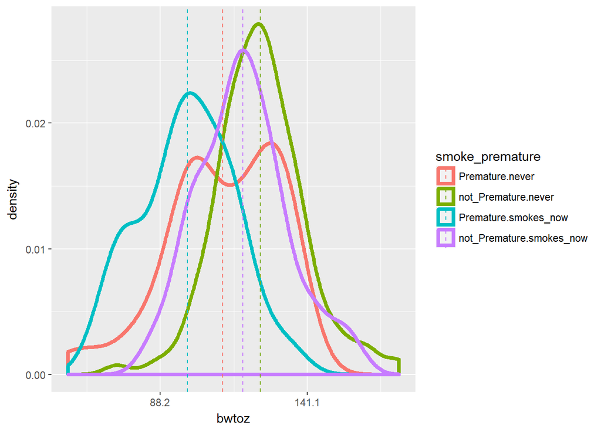

```r
babies$smoke_premature <- interaction(babies$Premature, babies$smoke)

mu <- ddply(na.omit(babies), "smoke_premature", summarise, s_p.mean=mean(bwtoz))
ggplot(na.omit(babies), aes(x=bwtoz, colour = smoke_premature)) +
  geom_density(size = 1.5) +
  scale_x_continuous(breaks=c(88.2, 141.1)) +
  geom_vline(data=mu, aes(xintercept=s_p.mean, color=smoke_premature),
             linetype="dashed")
```

One of the confounding factors in determining whether smoking effects pre-mature births and baby weight is the relationship between premature births and baby weight. Premature babies on average weight less than mature babies. There are many other factors that could lead to premature babies other than smoking. When trying to compare smoking and baby weight it’s difficult to tell if the difference in weight is do to smoking alone or if its also a side effect of smoking causing pre-mature births. With this graph I have paired up the factors of pre-mature births with smoking, and we can see that that the reduced baby weight from smoking is consistent amoung both mature and premature births. The dotted lines indicate the mean weight for each group, and the x-tick marks the lower and upper bound for healthy baby weight.

## Mother’s weight and birthweight for children

Here I’m finding out the relationship between mother’s weight and birthweight with respect to mothers who had premature babies (left) and mothers who had mature babies (right). The plot of these results is shown below

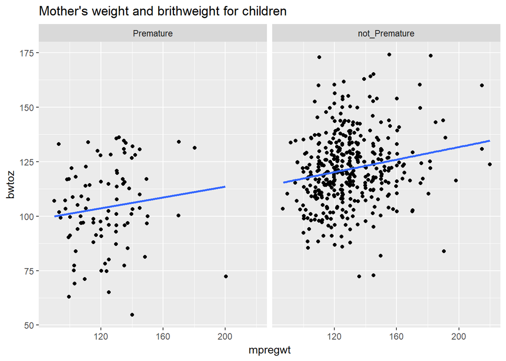

As we can see in this graph, there is a relationship between the mother’s pregnant weight and birthweight. However, there does not seem to be any difference in this relationship between pre-mature and mature births. Also side by side we can see that premature births have a generally lower birthweight than their mature counterparts, regardless of the mother’s pregnant weight.

## Does smooke affect the relationship between gestation and bwtoz?

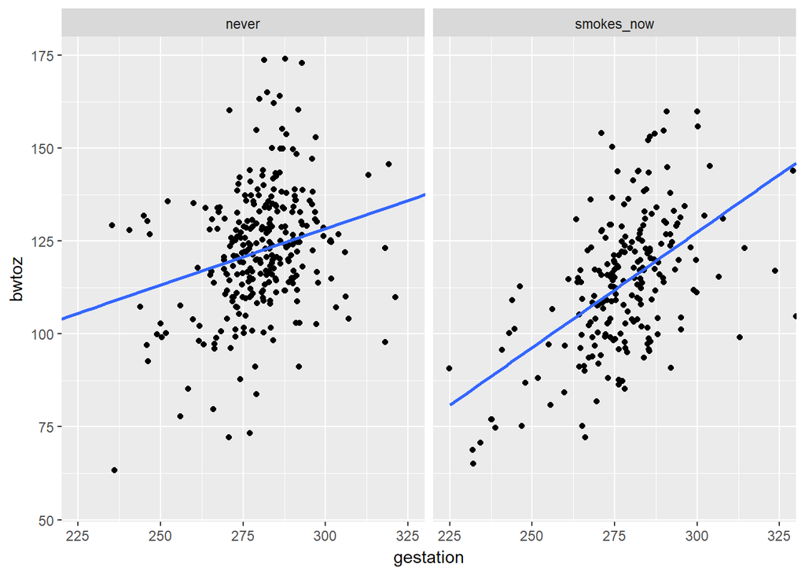

```r
ggplot(data=na.omit(babies),mapping=aes(x=gestation,y=bwtoz)) +
  geom_jitter() +
  geom_smooth(se=FALSE,method=lm) +
  facet_wrap(~smoke) +
  coord_cartesian(ylim=c(50,190)) +
  coord_cartesian(xlim=c(225,325))
```

## Individual Contributions

Sarah: For my contribution, I used geom_jitter, geom_abline, facet_wrap, geom_smooth, and ggtitle. I plotted mother’s height vs. weight, and separated the plots between mother’s that had premature children and mother’s who did not have premature children. I did this so we could see if having an unhealthy or healthy weight as the mother would tend to have an affect on the babies being premature. The results showed that there didn’t seem to be a significant difference in the trend; therefore, we could rule that out as a factor for our final conclusions.

Abby: I created a plot to determine if a baby’s birthweight was impacted by the Father’s weight. From those results I then created another set of plots to see if smoking made the relationship between Dad’s weight and birthweight stronger or weaker.

Derek: I created a plot to determine if smoking was causing a lower birthweight independant of whether the birth was premature, as well as an overall plot of the ratio of pre-mature births to mature births for smokers and non-smokers.

David: What I have done here is find the relationship between mother’s pregnant weight and baby’s birth weight. I have found that whether they have a premature baby or not, there is a correlation with the mother’s pregnant weigth and birthweight. Additionally, I found there are far fewer premature babies comparied to mature ones, and the birth weight for mature babies is higher than pre-mature ones.

Will: I created a plot to see the whether smoking could affect the relatioinship between gestation and bwtoz and also to see whether the smoking leads to a positive or negative impact.